SEIR calibration — real-data diagnosis

# Why the 5-method Utah COVID comparison was wrong, and what it says once fixed

Two independent bugs were saturating and destabilizing the classical/BiLSTM comparison on real surveillance data. Both are fixed; a third, ABC-SMC's boundary instability, remains open.

## Summary

The 5-method SEIR comparison (ABC-MCMC, ABC-SMC, Nelder–Mead, DE, BiLSTM) on Utah's first COVID-19 wave was giving nonsense because of two compounding bugs, not a fundamental flaw in the methods. Fixing both, 4 of 5 methods now converge to a consistent R₀ ≈ 1.2–2.1 for the first 60 days of the wave — a plausible range for a period with early interventions in effect.

2

bugs found & fixed

4 / 5

methods now agree

R₀ 1.2–2.1

converged range

1

method still unstable

## What was broken

01 BiLSTM saturated on every window Fixed

The predictor was fed Utah's true population (3,271,616) as an input feature, but the network trained only on simulated populations of 5,000–10,000 — roughly 650× outside its range. That pinned the sigmoid output head to its ceiling: **every one of the 17 windows tested (15–365 days, early/mid/late) predicted the identical `beta=1.2381`, `R0=5.00`**, exactly the scaler's maximum. The 5-method comparison was never actually exercising the model.

Fix: scale population and incidence into the trained range before calling the model (`real_data/bernardo_predict_real.py`), independent of whatever population the classical methods use.

02 Nelder–Mead degenerated in 1 dimension Fixed

Only one parameter (`beta`) is calibrated, so `optim(method="Nelder-Mead")` was optimizing in 1-D — R itself warns this is unreliable, since the simplex can't operate with fewer than 2 vertices. In practice it walked straight to a search-bound corner: `beta=10.0`, **R₀=100**.

Fix: switch to `optim(method="Brent")`, R's recommended 1-D method, over the same feasible range. Re-run: `beta=0.124`, R₀=1.24 — now in line with BiLSTM, ABC, and DE.

03 One population size served two incompatible needs Fixed

Fixing bug 01 by scaling everyone down to the BiLSTM's 5,000–10,000 range broke the classical optimizers: at that scale, Utah's real case counts become fractional (∼0.02–0.5 “cases/day”), which a single simulated integer SEIR trajectory can never match. That let an explosive early spike followed by near-zero for the rest of the window *out-score* a realistic epidemic on raw MSE against mostly-near-zero targets — independently reproducing the same failure mode as bug 02.

Fix: decouple the two. The BiLSTM keeps its own internal 8,000-population scaling (self-contained in its prediction script); the classical methods and the final plot use N=100,000, large enough to keep daily counts meaningfully non-fractional. `beta` is population-independent, so the BiLSTM's output plugs into the larger scale with no re-scaling needed.

04 ABC-SMC still finds a degenerate mode Open

Even after both fixes, ABC-SMC converged to `beta=1.87`, **R₀=18.7** — an epidemic that exhausts the population in about a month, then crashes to zero. This happened independently at two different population scales (8,000 and 100,000), so it isn't a scaling artifact: it looks like a real weakness in the sequential importance-resampling schedule (4 generations, median-based ε) letting a degenerate high-β particle cluster survive. ABC-MCMC, which explores the same raw-MSE objective by local random walk instead, did not have this problem — suggesting the issue is SMC-specific, not just the distance metric.

Recommended follow-up: port the summary-statistic + weighted-kernel design from the existing SIR `LFMCMC` calibration (peak height/day, phase means, weighted by observed magnitude) into the SEIR ABC/ABC-SMC objective, in place of raw windowed MSE.

## Results after the fix

Calibrated on the first 60 days of Utah's 365-day first wave (Mar 18 2020 – Mar 17 2021), N=100,000, recovery fixed at 1/10 day<sup>-1</sup>, incubation at 5 days. Each method's CI is 2,000 stochastic SEIR runs at its calibrated β.

### In-sample fit (the 60 calibration days themselves)

[output not shown]

### Full 365-day wave (extrapolation from a fixed 60-day fit)

[output not shown]

Low full-wave coverage for BiLSTM/NM/ABC/DE isn't a method failure — it's expected. A model with *constant* transmission fit to March–May 2020 has no way to know about the interventions, behavior change, and variants that shaped the rest of the year. It answers “how far does a static fit extrapolate,” a different question from in-sample accuracy.

## What the curves actually look like

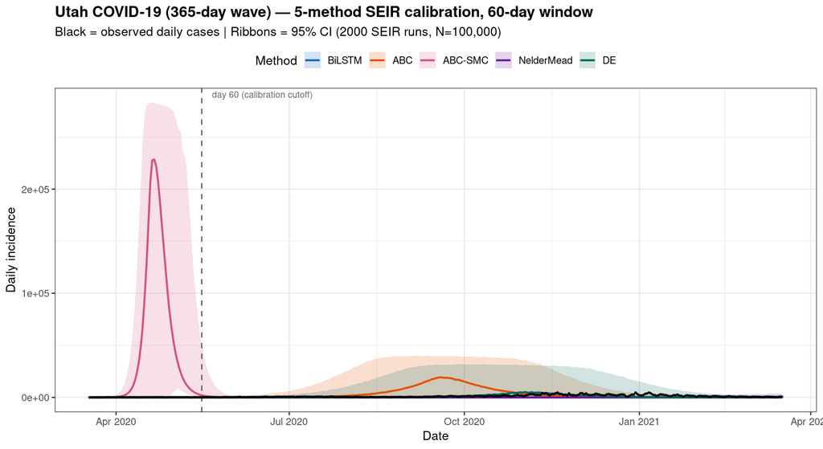

All 5 methods, unclipped y-axis. ABC-SMC (pink) peaks near 230,000/day around day 35, then collapses to zero as the population is exhausted — consistent with the boundary-mode diagnosis above.

Excluding ABC-SMC and capping the axis reveals what the other four methods are actually doing — and a genuinely interesting result: DE's fixed-parameter extrapolation, fit only to the flat, near-zero opening 60 days, tracks the rough shape and timing of Utah's real fall/winter surge reasonably well, months after its calibration window ended.

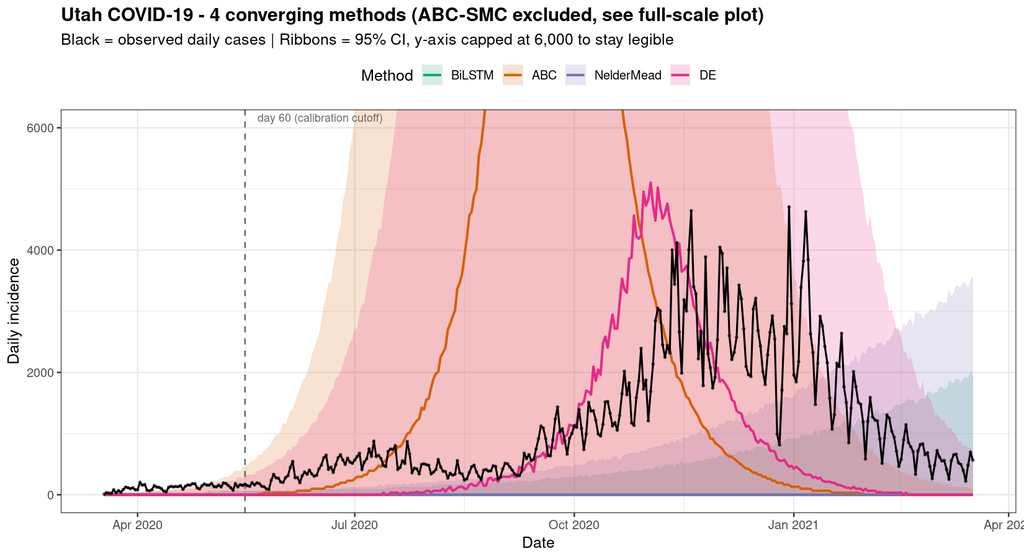

BiLSTM, ABC, Nelder–Mead, DE only; y-axis capped at 6,000 daily cases. BiLSTM and Nelder–Mead (R₀≈1.2, essentially sub-critical at this scale) stay near zero for the full year. DE's median (magenta) rises and peaks in a similar window to the real wave (black) — likely coincidental, since the model has no seasonality or behavior-change mechanism, but a striking extrapolation from 60 days of near-flat early data nonetheless.

## How this was produced

1. Diagnosed the BiLSTM saturation directly against the trained scaler bounds (`test_actual_parameters (2).csv`), confirmed by re-running predictions at a corrected population scale.
2. Fixed `bernardo_predict_real.py` and `calibrate_real_5method.R` (decoupled population scales, Brent for the 1-D NM case), and a separate `run_multiple_get_results()` parallel-cluster bug that broke on this cluster's custom library paths.
3. Calibration and all CI ensembles ran via SLURM on CHPC compute nodes (not the login node) — job IDs 14706894 (calibration) and 14708656 (final metrics/plot).
4. Metrics and plots regenerated directly from the saved per-day CI curves (`utah_covid_5method_ci_curves.csv`), no re-simulation needed.